# Risk Factor Analysis

## Outcome Variable

**Outcome Variable:** ever_stunted

## Predictor Variables

**Intervention Variable:** mbmi

**Adjustment Set:**

unadjusted

## Stratifying Variables

The analysis was stratified on these variable(s):

- agecat
- studyid
- country

## Data Summary

| agecat | studyid | country | mbmi | ever_stunted | n_cell | n |
| --- | --- | --- | --- | --- | --- | --- |
| 0-6 months | ki0047075b-MAL-ED | BANGLADESH | [18.5-25) | 0 | 134 | 254 |
| 0-6 months | ki0047075b-MAL-ED | BANGLADESH | [18.5-25) | 1 | 29 | 254 |
| 0-6 months | ki0047075b-MAL-ED | BANGLADESH | <18.5 | 0 | 27 | 254 |
| 0-6 months | ki0047075b-MAL-ED | BANGLADESH | <18.5 | 1 | 5 | 254 |
| 0-6 months | ki0047075b-MAL-ED | BANGLADESH | [25-30) | 0 | 48 | 254 |
| 0-6 months | ki0047075b-MAL-ED | BANGLADESH | [25-30) | 1 | 5 | 254 |
| 0-6 months | ki0047075b-MAL-ED | BANGLADESH | >=30 | 0 | 2 | 254 |
| 0-6 months | ki0047075b-MAL-ED | BANGLADESH | >=30 | 1 | 4 | 254 |
| 0-6 months | ki0047075b-MAL-ED | BRAZIL | [18.5-25) | 0 | 79 | 221 |
| 0-6 months | ki0047075b-MAL-ED | BRAZIL | [18.5-25) | 1 | 9 | 221 |
| 0-6 months | ki0047075b-MAL-ED | BRAZIL | <18.5 | 0 | 8 | 221 |
| 0-6 months | ki0047075b-MAL-ED | BRAZIL | <18.5 | 1 | 2 | 221 |
| 0-6 months | ki0047075b-MAL-ED | BRAZIL | [25-30) | 0 | 74 | 221 |
| 0-6 months | ki0047075b-MAL-ED | BRAZIL | [25-30) | 1 | 8 | 221 |
| 0-6 months | ki0047075b-MAL-ED | BRAZIL | >=30 | 0 | 38 | 221 |
| 0-6 months | ki0047075b-MAL-ED | BRAZIL | >=30 | 1 | 3 | 221 |
| 0-6 months | ki0047075b-MAL-ED | INDIA | [18.5-25) | 0 | 115 | 242 |
| 0-6 months | ki0047075b-MAL-ED | INDIA | [18.5-25) | 1 | 27 | 242 |
| 0-6 months | ki0047075b-MAL-ED | INDIA | <18.5 | 0 | 40 | 242 |
| 0-6 months | ki0047075b-MAL-ED | INDIA | <18.5 | 1 | 9 | 242 |
| 0-6 months | ki0047075b-MAL-ED | INDIA | [25-30) | 0 | 36 | 242 |
| 0-6 months | ki0047075b-MAL-ED | INDIA | [25-30) | 1 | 4 | 242 |
| 0-6 months | ki0047075b-MAL-ED | INDIA | >=30 | 0 | 10 | 242 |
| 0-6 months | ki0047075b-MAL-ED | INDIA | >=30 | 1 | 1 | 242 |
| 0-6 months | ki0047075b-MAL-ED | NEPAL | [18.5-25) | 0 | 118 | 238 |
| 0-6 months | ki0047075b-MAL-ED | NEPAL | [18.5-25) | 1 | 16 | 238 |
| 0-6 months | ki0047075b-MAL-ED | NEPAL | [25-30) | 0 | 78 | 238 |
| 0-6 months | ki0047075b-MAL-ED | NEPAL | [25-30) | 1 | 9 | 238 |
| 0-6 months | ki0047075b-MAL-ED | NEPAL | >=30 | 0 | 15 | 238 |
| 0-6 months | ki0047075b-MAL-ED | NEPAL | >=30 | 1 | 2 | 238 |

[output cut: 338 more lines]

The following strata were considered:

- agecat: 0-24 months, studyid: ki0047075b-MAL-ED, country: BANGLADESH
- agecat: 0-24 months, studyid: ki0047075b-MAL-ED, country: BRAZIL
- agecat: 0-24 months, studyid: ki0047075b-MAL-ED, country: INDIA
- agecat: 0-24 months, studyid: ki0047075b-MAL-ED, country: NEPAL
- agecat: 0-24 months, studyid: ki0047075b-MAL-ED, country: PERU
- agecat: 0-24 months, studyid: ki0047075b-MAL-ED, country: SOUTH AFRICA
- agecat: 0-24 months, studyid: ki0047075b-MAL-ED, country: TANZANIA, UNITED REPUBLIC OF
- agecat: 0-24 months, studyid: ki1000304b-SAS-CompFeed, country: INDIA
- agecat: 0-24 months, studyid: ki1017093-NIH-Birth, country: BANGLADESH
- agecat: 0-24 months, studyid: ki1017093b-PROVIDE, country: BANGLADESH
- agecat: 0-24 months, studyid: ki1017093c-NIH-Crypto, country: BANGLADESH
- agecat: 0-24 months, studyid: ki1066203-TanzaniaChild2, country: TANZANIA, UNITED REPUBLIC OF
- agecat: 0-24 months, studyid: ki1112895-iLiNS-Zinc, country: BURKINA FASO
- agecat: 0-24 months, studyid: ki1119695-PROBIT, country: BELARUS
- agecat: 0-24 months, studyid: ki1126311-ZVITAMBO, country: ZIMBABWE
- agecat: 0-24 months, studyid: ki1148112-LCNI-5, country: MALAWI
- agecat: 0-6 months, studyid: ki0047075b-MAL-ED, country: BANGLADESH
- agecat: 0-6 months, studyid: ki0047075b-MAL-ED, country: BRAZIL
- agecat: 0-6 months, studyid: ki0047075b-MAL-ED, country: INDIA
- agecat: 0-6 months, studyid: ki0047075b-MAL-ED, country: NEPAL
- agecat: 0-6 months, studyid: ki0047075b-MAL-ED, country: PERU
- agecat: 0-6 months, studyid: ki0047075b-MAL-ED, country: SOUTH AFRICA
- agecat: 0-6 months, studyid: ki0047075b-MAL-ED, country: TANZANIA, UNITED REPUBLIC OF
- agecat: 0-6 months, studyid: ki1000304b-SAS-CompFeed, country: INDIA
- agecat: 0-6 months, studyid: ki1017093-NIH-Birth, country: BANGLADESH
- agecat: 0-6 months, studyid: ki1017093b-PROVIDE, country: BANGLADESH
- agecat: 0-6 months, studyid: ki1017093c-NIH-Crypto, country: BANGLADESH
- agecat: 0-6 months, studyid: ki1066203-TanzaniaChild2, country: TANZANIA, UNITED REPUBLIC OF
- agecat: 0-6 months, studyid: ki1119695-PROBIT, country: BELARUS
- agecat: 0-6 months, studyid: ki1126311-ZVITAMBO, country: ZIMBABWE
- agecat: 0-6 months, studyid: ki1148112-LCNI-5, country: MALAWI
- agecat: 6-24 months, studyid: ki0047075b-MAL-ED, country: BANGLADESH
- agecat: 6-24 months, studyid: ki0047075b-MAL-ED, country: BRAZIL
- agecat: 6-24 months, studyid: ki0047075b-MAL-ED, country: INDIA
- agecat: 6-24 months, studyid: ki0047075b-MAL-ED, country: NEPAL
- agecat: 6-24 months, studyid: ki0047075b-MAL-ED, country: PERU
- agecat: 6-24 months, studyid: ki0047075b-MAL-ED, country: SOUTH AFRICA
- agecat: 6-24 months, studyid: ki0047075b-MAL-ED, country: TANZANIA, UNITED REPUBLIC OF
- agecat: 6-24 months, studyid: ki1000304b-SAS-CompFeed, country: INDIA
- agecat: 6-24 months, studyid: ki1017093-NIH-Birth, country: BANGLADESH
- agecat: 6-24 months, studyid: ki1017093b-PROVIDE, country: BANGLADESH
- agecat: 6-24 months, studyid: ki1017093c-NIH-Crypto, country: BANGLADESH
- agecat: 6-24 months, studyid: ki1066203-TanzaniaChild2, country: TANZANIA, UNITED REPUBLIC OF
- agecat: 6-24 months, studyid: ki1112895-iLiNS-Zinc, country: BURKINA FASO
- agecat: 6-24 months, studyid: ki1119695-PROBIT, country: BELARUS
- agecat: 6-24 months, studyid: ki1126311-ZVITAMBO, country: ZIMBABWE
- agecat: 6-24 months, studyid: ki1148112-LCNI-5, country: MALAWI

### Dropped Strata

Some strata were dropped due to rare outcomes:

- agecat: 0-6 months, studyid: ki0047075b-MAL-ED, country: BANGLADESH
- agecat: 0-6 months, studyid: ki0047075b-MAL-ED, country: BRAZIL
- agecat: 0-6 months, studyid: ki0047075b-MAL-ED, country: INDIA
- agecat: 0-6 months, studyid: ki0047075b-MAL-ED, country: NEPAL
- agecat: 0-6 months, studyid: ki0047075b-MAL-ED, country: PERU
- agecat: 0-6 months, studyid: ki0047075b-MAL-ED, country: SOUTH AFRICA
- agecat: 0-6 months, studyid: ki0047075b-MAL-ED, country: TANZANIA, UNITED REPUBLIC OF
- agecat: 0-6 months, studyid: ki1000304b-SAS-CompFeed, country: INDIA
- agecat: 0-6 months, studyid: ki1017093-NIH-Birth, country: BANGLADESH
- agecat: 0-6 months, studyid: ki1017093b-PROVIDE, country: BANGLADESH
- agecat: 0-6 months, studyid: ki1017093c-NIH-Crypto, country: BANGLADESH
- agecat: 0-6 months, studyid: ki1066203-TanzaniaChild2, country: TANZANIA, UNITED REPUBLIC OF
- agecat: 0-6 months, studyid: ki1119695-PROBIT, country: BELARUS
- agecat: 0-6 months, studyid: ki1148112-LCNI-5, country: MALAWI
- agecat: 6-24 months, studyid: ki0047075b-MAL-ED, country: BANGLADESH
- agecat: 6-24 months, studyid: ki0047075b-MAL-ED, country: BRAZIL
- agecat: 6-24 months, studyid: ki0047075b-MAL-ED, country: INDIA
- agecat: 6-24 months, studyid: ki0047075b-MAL-ED, country: NEPAL
- agecat: 6-24 months, studyid: ki0047075b-MAL-ED, country: PERU
- agecat: 6-24 months, studyid: ki0047075b-MAL-ED, country: SOUTH AFRICA
- agecat: 6-24 months, studyid: ki0047075b-MAL-ED, country: TANZANIA, UNITED REPUBLIC OF
- agecat: 6-24 months, studyid: ki1000304b-SAS-CompFeed, country: INDIA
- agecat: 6-24 months, studyid: ki1017093-NIH-Birth, country: BANGLADESH
- agecat: 6-24 months, studyid: ki1017093b-PROVIDE, country: BANGLADESH
- agecat: 6-24 months, studyid: ki1017093c-NIH-Crypto, country: BANGLADESH
- agecat: 6-24 months, studyid: ki1148112-LCNI-5, country: MALAWI
- agecat: 0-24 months, studyid: ki0047075b-MAL-ED, country: BANGLADESH
- agecat: 0-24 months, studyid: ki0047075b-MAL-ED, country: BRAZIL
- agecat: 0-24 months, studyid: ki0047075b-MAL-ED, country: NEPAL
- agecat: 0-24 months, studyid: ki0047075b-MAL-ED, country: PERU
- agecat: 0-24 months, studyid: ki0047075b-MAL-ED, country: SOUTH AFRICA
- agecat: 0-24 months, studyid: ki0047075b-MAL-ED, country: TANZANIA, UNITED REPUBLIC OF
- agecat: 0-24 months, studyid: ki1000304b-SAS-CompFeed, country: INDIA
- agecat: 0-24 months, studyid: ki1148112-LCNI-5, country: MALAWI

## Methods Detail

We’re interested in the causal parameters $E[Y_a]$ for all values of $a \in \mathcal{A}$. These parameters represent the mean outcome if, possibly contrary to fact, we intervened to set all units to have $A=a$. Under the randomization and positivity assumptions, these are identified by the statistical parameters $\psi_a=E_W[E_{Y|A,W}(Y|A=a,W)]$. In addition, we’re interested in the mean of $Y$, $E[Y]$ under no intervention (the observed mean). We will estimate these parameters by using SuperLearner to fit the relevant likelihood factors – $E_{Y|A,W}(Y|A=a,W)$ and $p(A=a|W)$, and then updating our likelihood fit using a joint TMLE.

For unadjusted analyses ($W=\{\}$), initial likelihoods were estimated using Lrnr_glm to estimate the simple $E(Y|A)$ and Lrnr_mean to estimate $p(A)$. For adjusted analyses, a small library containing Lrnr_glmnet, Lrnr_xgboost, and Lrnr_mean was used.

Having estimated these parameters, we will then use the delta method to estimate relative risks and attributable risks relative to a prespecified baseline level of $A$.

# Results Detail

## Results Plots

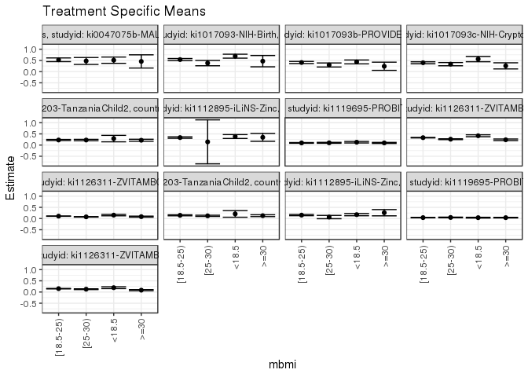

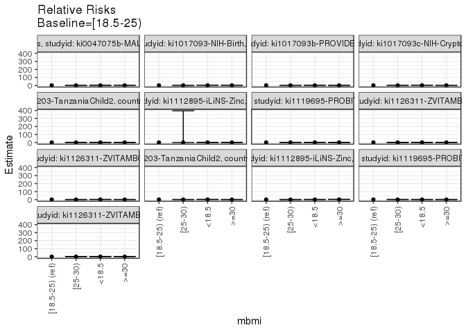

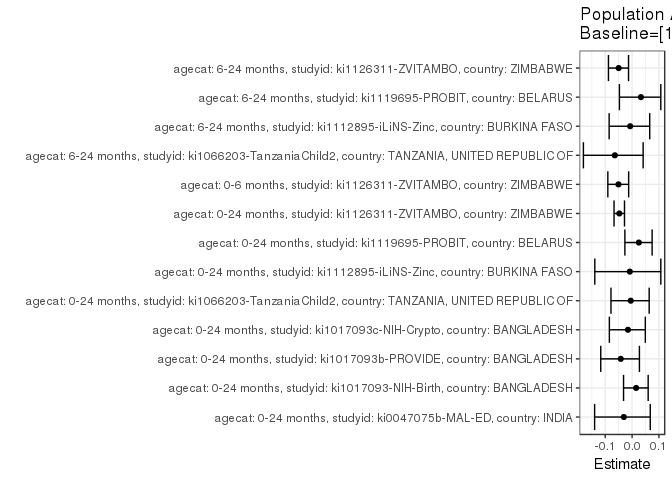

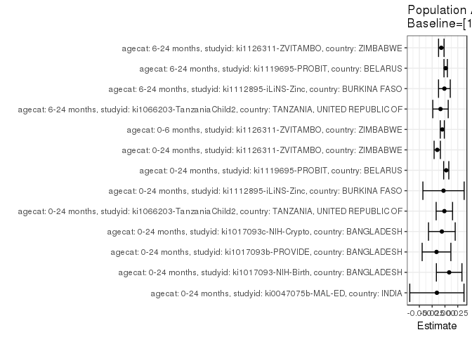

## Results Table

### Parameter: TSM

| agecat | studyid | country | intervention_level | baseline_level | estimate | ci_lower | ci_upper |
| --- | --- | --- | --- | --- | --- | --- | --- |
| 0-24 months | ki0047075b-MAL-ED | INDIA | [18.5-25) | NA | 0.5281690 | 0.4458912 | 0.6104468 |
| 0-24 months | ki0047075b-MAL-ED | INDIA | <18.5 | NA | 0.5102041 | 0.3699457 | 0.6504624 |
| 0-24 months | ki0047075b-MAL-ED | INDIA | [25-30) | NA | 0.4750000 | 0.3199243 | 0.6300757 |
| 0-24 months | ki0047075b-MAL-ED | INDIA | >=30 | NA | 0.4545455 | 0.1596834 | 0.7494075 |
| 0-24 months | ki1017093-NIH-Birth | BANGLADESH | [18.5-25) | NA | 0.5370787 | 0.4907141 | 0.5834432 |
| 0-24 months | ki1017093-NIH-Birth | BANGLADESH | <18.5 | NA | 0.6886792 | 0.6004621 | 0.7768964 |
| 0-24 months | ki1017093-NIH-Birth | BANGLADESH | [25-30) | NA | 0.3809524 | 0.2609415 | 0.5009633 |
| 0-24 months | ki1017093-NIH-Birth | BANGLADESH | >=30 | NA | 0.4666667 | 0.2139984 | 0.7193349 |
| 0-24 months | ki1017093b-PROVIDE | BANGLADESH | [18.5-25) | NA | 0.4066194 | 0.3597744 | 0.4534644 |
| 0-24 months | ki1017093b-PROVIDE | BANGLADESH | <18.5 | NA | 0.4330709 | 0.3468296 | 0.5193121 |
| 0-24 months | ki1017093b-PROVIDE | BANGLADESH | [25-30) | NA | 0.2959184 | 0.2054790 | 0.3863577 |
| 0-24 months | ki1017093b-PROVIDE | BANGLADESH | >=30 | NA | 0.2380952 | 0.0557943 | 0.4203962 |
| 0-24 months | ki1017093c-NIH-Crypto | BANGLADESH | [18.5-25) | NA | 0.3954451 | 0.3518113 | 0.4390790 |
| 0-24 months | ki1017093c-NIH-Crypto | BANGLADESH | <18.5 | NA | 0.5588235 | 0.4407303 | 0.6769167 |
| 0-24 months | ki1017093c-NIH-Crypto | BANGLADESH | [25-30) | NA | 0.3333333 | 0.2613573 | 0.4053093 |
| 0-24 months | ki1017093c-NIH-Crypto | BANGLADESH | >=30 | NA | 0.2564103 | 0.1192785 | 0.3935420 |
| 0-24 months | ki1066203-TanzaniaChild2 | TANZANIA, UNITED REPUBLIC OF | [18.5-25) | NA | 0.2267206 | 0.2033634 | 0.2500779 |
| 0-24 months | ki1066203-TanzaniaChild2 | TANZANIA, UNITED REPUBLIC OF | <18.5 | NA | 0.2894737 | 0.1452477 | 0.4336997 |
| 0-24 months | ki1066203-TanzaniaChild2 | TANZANIA, UNITED REPUBLIC OF | [25-30) | NA | 0.2250674 | 0.1950117 | 0.2551231 |
| 0-24 months | ki1066203-TanzaniaChild2 | TANZANIA, UNITED REPUBLIC OF | >=30 | NA | 0.2151515 | 0.1708061 | 0.2594969 |
| 0-24 months | ki1112895-iLiNS-Zinc | BURKINA FASO | [18.5-25) | NA | 0.3342520 | 0.3015817 | 0.3669222 |
| 0-24 months | ki1112895-iLiNS-Zinc | BURKINA FASO | <18.5 | NA | 0.3813747 | 0.2943445 | 0.4684050 |
| 0-24 months | ki1112895-iLiNS-Zinc | BURKINA FASO | [25-30) | NA | 0.1437500 | -0.8375977 | 1.1250977 |
| 0-24 months | ki1112895-iLiNS-Zinc | BURKINA FASO | >=30 | NA | 0.3461538 | 0.1696740 | 0.5226337 |
| 0-24 months | ki1119695-PROBIT | BELARUS | [18.5-25) | NA | 0.0964299 | 0.0798772 | 0.1129826 |
| 0-24 months | ki1119695-PROBIT | BELARUS | <18.5 | NA | 0.1281071 | 0.0944718 | 0.1617424 |
| 0-24 months | ki1119695-PROBIT | BELARUS | [25-30) | NA | 0.1010789 | 0.0814396 | 0.1207183 |
| 0-24 months | ki1119695-PROBIT | BELARUS | >=30 | NA | 0.0972585 | 0.0742997 | 0.1202172 |
| 0-24 months | ki1126311-ZVITAMBO | ZIMBABWE | [18.5-25) | NA | 0.3309545 | 0.3197084 | 0.3422007 |
| 0-24 months | ki1126311-ZVITAMBO | ZIMBABWE | <18.5 | NA | 0.4158607 | 0.3733736 | 0.4583478 |
| 0-24 months | ki1126311-ZVITAMBO | ZIMBABWE | [25-30) | NA | 0.2623936 | 0.2430975 | 0.2816897 |
| 0-24 months | ki1126311-ZVITAMBO | ZIMBABWE | >=30 | NA | 0.2366149 | 0.2019951 | 0.2712346 |
| 0-6 months | ki1126311-ZVITAMBO | ZIMBABWE | [18.5-25) | NA | 0.1067282 | 0.0993444 | 0.1141120 |
| 0-6 months | ki1126311-ZVITAMBO | ZIMBABWE | <18.5 | NA | 0.1528046 | 0.1217887 | 0.1838206 |
| 0-6 months | ki1126311-ZVITAMBO | ZIMBABWE | [25-30) | NA | 0.0757652 | 0.0641469 | 0.0873835 |
| 0-6 months | ki1126311-ZVITAMBO | ZIMBABWE | >=30 | NA | 0.0846287 | 0.0619567 | 0.1073006 |
| 6-24 months | ki1066203-TanzaniaChild2 | TANZANIA, UNITED REPUBLIC OF | [18.5-25) | NA | 0.1442206 | 0.1217917 | 0.1666494 |
| 6-24 months | ki1066203-TanzaniaChild2 | TANZANIA, UNITED REPUBLIC OF | <18.5 | NA | 0.2068966 | 0.0594241 | 0.3543690 |
| 6-24 months | ki1066203-TanzaniaChild2 | TANZANIA, UNITED REPUBLIC OF | [25-30) | NA | 0.1211073 | 0.0945026 | 0.1477119 |
| 6-24 months | ki1066203-TanzaniaChild2 | TANZANIA, UNITED REPUBLIC OF | >=30 | NA | 0.1279070 | 0.0871420 | 0.1686719 |
| 6-24 months | ki1112895-iLiNS-Zinc | BURKINA FASO | [18.5-25) | NA | 0.1531146 | 0.1261904 | 0.1800388 |
| 6-24 months | ki1112895-iLiNS-Zinc | BURKINA FASO | <18.5 | NA | 0.1746479 | 0.1254779 | 0.2238179 |
| 6-24 months | ki1112895-iLiNS-Zinc | BURKINA FASO | [25-30) | NA | 0.0666667 | -0.0074756 | 0.1408089 |
| 6-24 months | ki1112895-iLiNS-Zinc | BURKINA FASO | >=30 | NA | 0.2608696 | 0.1208590 | 0.4008802 |
| 6-24 months | ki1119695-PROBIT | BELARUS | [18.5-25) | NA | 0.0413553 | 0.0311366 | 0.0515739 |
| 6-24 months | ki1119695-PROBIT | BELARUS | <18.5 | NA | 0.0395257 | 0.0229092 | 0.0561422 |
| 6-24 months | ki1119695-PROBIT | BELARUS | [25-30) | NA | 0.0477149 | 0.0330893 | 0.0623404 |
| 6-24 months | ki1119695-PROBIT | BELARUS | >=30 | NA | 0.0399202 | 0.0260096 | 0.0538307 |
| 6-24 months | ki1126311-ZVITAMBO | ZIMBABWE | [18.5-25) | NA | 0.1499206 | 0.1400602 | 0.1597810 |
| 6-24 months | ki1126311-ZVITAMBO | ZIMBABWE | <18.5 | NA | 0.1939891 | 0.1534759 | 0.2345022 |
| 6-24 months | ki1126311-ZVITAMBO | ZIMBABWE | [25-30) | NA | 0.1256443 | 0.1091533 | 0.1421353 |
| 6-24 months | ki1126311-ZVITAMBO | ZIMBABWE | >=30 | NA | 0.0820735 | 0.0570705 | 0.1070765 |

### Parameter: E(Y)

| agecat | studyid | country | intervention_level | baseline_level | estimate | ci_lower | ci_upper |
| --- | --- | --- | --- | --- | --- | --- | --- |
| 0-24 months | ki0047075b-MAL-ED | INDIA | NA | NA | 0.5123967 | 0.4492899 | 0.5755035 |
| 0-24 months | ki1017093-NIH-Birth | BANGLADESH | NA | NA | 0.5453100 | 0.5063654 | 0.5842547 |
| 0-24 months | ki1017093b-PROVIDE | BANGLADESH | NA | NA | 0.3901345 | 0.3531446 | 0.4271245 |
| 0-24 months | ki1017093c-NIH-Crypto | BANGLADESH | NA | NA | 0.3894040 | 0.3545991 | 0.4242088 |
| 0-24 months | ki1066203-TanzaniaChild2 | TANZANIA, UNITED REPUBLIC OF | NA | NA | 0.2255864 | 0.2086659 | 0.2425068 |
| 0-24 months | ki1112895-iLiNS-Zinc | BURKINA FASO | NA | NA | 0.3314448 | 0.2804289 | 0.3824606 |
| 0-24 months | ki1119695-PROBIT | BELARUS | NA | NA | 0.0989219 | 0.0828371 | 0.1150068 |
| 0-24 months | ki1126311-ZVITAMBO | ZIMBABWE | NA | NA | 0.3159181 | 0.3067226 | 0.3251137 |
| 0-6 months | ki1126311-ZVITAMBO | ZIMBABWE | NA | NA | 0.1015601 | 0.0955814 | 0.1075388 |
| 6-24 months | ki1066203-TanzaniaChild2 | TANZANIA, UNITED REPUBLIC OF | NA | NA | 0.1355088 | 0.1197279 | 0.1512898 |
| 6-24 months | ki1112895-iLiNS-Zinc | BURKINA FASO | NA | NA | 0.1520334 | 0.1259980 | 0.1780689 |
| 6-24 months | ki1119695-PROBIT | BELARUS | NA | NA | 0.0427641 | 0.0326485 | 0.0528797 |
| 6-24 months | ki1126311-ZVITAMBO | ZIMBABWE | NA | NA | 0.1427801 | 0.1348177 | 0.1507425 |

### Parameter: RR

| agecat | studyid | country | intervention_level | baseline_level | estimate | ci_lower | ci_upper |
| --- | --- | --- | --- | --- | --- | --- | --- |
| 0-24 months | ki0047075b-MAL-ED | INDIA | [18.5-25) | [18.5-25) | 1.0000000 | 1.0000000 | 1.0000000 |
| 0-24 months | ki0047075b-MAL-ED | INDIA | <18.5 | [18.5-25) | 0.9659864 | 0.7042785 | 1.3249441 |
| 0-24 months | ki0047075b-MAL-ED | INDIA | [25-30) | [18.5-25) | 0.8993333 | 0.6263550 | 1.2912811 |
| 0-24 months | ki0047075b-MAL-ED | INDIA | >=30 | [18.5-25) | 0.8606061 | 0.4416413 | 1.6770235 |
| 0-24 months | ki1017093-NIH-Birth | BANGLADESH | [18.5-25) | [18.5-25) | 1.0000000 | 1.0000000 | 1.0000000 |
| 0-24 months | ki1017093-NIH-Birth | BANGLADESH | <18.5 | [18.5-25) | 1.2822689 | 1.0987365 | 1.4964584 |
| 0-24 months | ki1017093-NIH-Birth | BANGLADESH | [25-30) | [18.5-25) | 0.7093046 | 0.5116508 | 0.9833133 |
| 0-24 months | ki1017093-NIH-Birth | BANGLADESH | >=30 | [18.5-25) | 0.8688982 | 0.5021782 | 1.5034187 |
| 0-24 months | ki1017093b-PROVIDE | BANGLADESH | [18.5-25) | [18.5-25) | 1.0000000 | 1.0000000 | 1.0000000 |
| 0-24 months | ki1017093b-PROVIDE | BANGLADESH | <18.5 | [18.5-25) | 1.0650522 | 0.8461669 | 1.3405584 |
| 0-24 months | ki1017093b-PROVIDE | BANGLADESH | [25-30) | [18.5-25) | 0.7277527 | 0.5249725 | 1.0088604 |
| 0-24 months | ki1017093b-PROVIDE | BANGLADESH | >=30 | [18.5-25) | 0.5855482 | 0.2699578 | 1.2700751 |
| 0-24 months | ki1017093c-NIH-Crypto | BANGLADESH | [18.5-25) | [18.5-25) | 1.0000000 | 1.0000000 | 1.0000000 |
| 0-24 months | ki1017093c-NIH-Crypto | BANGLADESH | <18.5 | [18.5-25) | 1.4131506 | 1.1134067 | 1.7935896 |
| 0-24 months | ki1017093c-NIH-Crypto | BANGLADESH | [25-30) | [18.5-25) | 0.8429319 | 0.6614266 | 1.0742450 |
| 0-24 months | ki1017093c-NIH-Crypto | BANGLADESH | >=30 | [18.5-25) | 0.6484092 | 0.3755697 | 1.1194578 |
| 0-24 months | ki1066203-TanzaniaChild2 | TANZANIA, UNITED REPUBLIC OF | [18.5-25) | [18.5-25) | 1.0000000 | 1.0000000 | 1.0000000 |
| 0-24 months | ki1066203-TanzaniaChild2 | TANZANIA, UNITED REPUBLIC OF | <18.5 | [18.5-25) | 1.2767857 | 0.7676440 | 2.1236168 |
| 0-24 months | ki1066203-TanzaniaChild2 | TANZANIA, UNITED REPUBLIC OF | [25-30) | [18.5-25) | 0.9927079 | 0.8386345 | 1.1750877 |
| 0-24 months | ki1066203-TanzaniaChild2 | TANZANIA, UNITED REPUBLIC OF | >=30 | [18.5-25) | 0.9489719 | 0.7536693 | 1.1948843 |
| 0-24 months | ki1112895-iLiNS-Zinc | BURKINA FASO | [18.5-25) | [18.5-25) | 1.0000000 | 1.0000000 | 1.0000000 |
| 0-24 months | ki1112895-iLiNS-Zinc | BURKINA FASO | <18.5 | [18.5-25) | 1.1409797 | 0.9176829 | 1.4186106 |
| 0-24 months | ki1112895-iLiNS-Zinc | BURKINA FASO | [25-30) | [18.5-25) | 0.4300648 | 0.0004671 | 396.0027508 |
| 0-24 months | ki1112895-iLiNS-Zinc | BURKINA FASO | >=30 | [18.5-25) | 1.0356075 | 0.6244396 | 1.7175127 |
| 0-24 months | ki1119695-PROBIT | BELARUS | [18.5-25) | [18.5-25) | 1.0000000 | 1.0000000 | 1.0000000 |
| 0-24 months | ki1119695-PROBIT | BELARUS | <18.5 | [18.5-25) | 1.3284997 | 1.0425122 | 1.6929407 |
| 0-24 months | ki1119695-PROBIT | BELARUS | [25-30) | [18.5-25) | 1.0482117 | 0.9002617 | 1.2204759 |
| 0-24 months | ki1119695-PROBIT | BELARUS | >=30 | [18.5-25) | 1.0085928 | 0.8391543 | 1.2122435 |
| 0-24 months | ki1126311-ZVITAMBO | ZIMBABWE | [18.5-25) | [18.5-25) | 1.0000000 | 1.0000000 | 1.0000000 |
| 0-24 months | ki1126311-ZVITAMBO | ZIMBABWE | <18.5 | [18.5-25) | 1.2565496 | 1.1282863 | 1.3993937 |
| 0-24 months | ki1126311-ZVITAMBO | ZIMBABWE | [25-30) | [18.5-25) | 0.7928389 | 0.7311435 | 0.8597402 |
| 0-24 months | ki1126311-ZVITAMBO | ZIMBABWE | >=30 | [18.5-25) | 0.7149468 | 0.6152331 | 0.8308214 |
| 0-6 months | ki1126311-ZVITAMBO | ZIMBABWE | [18.5-25) | [18.5-25) | 1.0000000 | 1.0000000 | 1.0000000 |
| 0-6 months | ki1126311-ZVITAMBO | ZIMBABWE | <18.5 | [18.5-25) | 1.4317177 | 1.1553816 | 1.7741459 |
| 0-6 months | ki1126311-ZVITAMBO | ZIMBABWE | [25-30) | [18.5-25) | 0.7098891 | 0.5999693 | 0.8399471 |
| 0-6 months | ki1126311-ZVITAMBO | ZIMBABWE | >=30 | [18.5-25) | 0.7929364 | 0.6012767 | 1.0456885 |
| 6-24 months | ki1066203-TanzaniaChild2 | TANZANIA, UNITED REPUBLIC OF | [18.5-25) | [18.5-25) | 1.0000000 | 1.0000000 | 1.0000000 |
| 6-24 months | ki1066203-TanzaniaChild2 | TANZANIA, UNITED REPUBLIC OF | <18.5 | [18.5-25) | 1.4345842 | 0.6916490 | 2.9755438 |
| 6-24 months | ki1066203-TanzaniaChild2 | TANZANIA, UNITED REPUBLIC OF | [25-30) | [18.5-25) | 0.8397364 | 0.6415796 | 1.0990955 |
| 6-24 months | ki1066203-TanzaniaChild2 | TANZANIA, UNITED REPUBLIC OF | >=30 | [18.5-25) | 0.8868844 | 0.6220917 | 1.2643858 |
| 6-24 months | ki1112895-iLiNS-Zinc | BURKINA FASO | [18.5-25) | [18.5-25) | 1.0000000 | 1.0000000 | 1.0000000 |
| 6-24 months | ki1112895-iLiNS-Zinc | BURKINA FASO | <18.5 | [18.5-25) | 1.1406351 | 0.8568480 | 1.5184123 |
| 6-24 months | ki1112895-iLiNS-Zinc | BURKINA FASO | [25-30) | [18.5-25) | 0.4354037 | 0.1423355 | 1.3318979 |
| 6-24 months | ki1112895-iLiNS-Zinc | BURKINA FASO | >=30 | [18.5-25) | 1.7037537 | 0.9746637 | 2.9782342 |
| 6-24 months | ki1119695-PROBIT | BELARUS | [18.5-25) | [18.5-25) | 1.0000000 | 1.0000000 | 1.0000000 |
| 6-24 months | ki1119695-PROBIT | BELARUS | <18.5 | [18.5-25) | 0.9557598 | 0.6259341 | 1.4593818 |
| 6-24 months | ki1119695-PROBIT | BELARUS | [25-30) | [18.5-25) | 1.1537798 | 0.9393214 | 1.4172017 |
| 6-24 months | ki1119695-PROBIT | BELARUS | >=30 | [18.5-25) | 0.9652983 | 0.6769718 | 1.3764250 |
| 6-24 months | ki1126311-ZVITAMBO | ZIMBABWE | [18.5-25) | [18.5-25) | 1.0000000 | 1.0000000 | 1.0000000 |
| 6-24 months | ki1126311-ZVITAMBO | ZIMBABWE | <18.5 | [18.5-25) | 1.2939456 | 1.0395022 | 1.6106703 |
| 6-24 months | ki1126311-ZVITAMBO | ZIMBABWE | [25-30) | [18.5-25) | 0.8380726 | 0.7236416 | 0.9705989 |
| 6-24 months | ki1126311-ZVITAMBO | ZIMBABWE | >=30 | [18.5-25) | 0.5474464 | 0.4008566 | 0.7476427 |

### Parameter: PAR

| agecat | studyid | country | intervention_level | baseline_level | estimate | ci_lower | ci_upper |
| --- | --- | --- | --- | --- | --- | --- | --- |
| 0-24 months | ki0047075b-MAL-ED | INDIA | [18.5-25) | NA | -0.0157723 | -0.0687588 | 0.0372142 |
| 0-24 months | ki1017093-NIH-Birth | BANGLADESH | [18.5-25) | NA | 0.0082314 | -0.0167624 | 0.0332252 |
| 0-24 months | ki1017093b-PROVIDE | BANGLADESH | [18.5-25) | NA | -0.0164849 | -0.0445502 | 0.0115805 |
| 0-24 months | ki1017093c-NIH-Crypto | BANGLADESH | [18.5-25) | NA | -0.0060412 | -0.0321044 | 0.0200220 |
| 0-24 months | ki1066203-TanzaniaChild2 | TANZANIA, UNITED REPUBLIC OF | [18.5-25) | NA | -0.0011343 | -0.0171724 | 0.0149038 |
| 0-24 months | ki1112895-iLiNS-Zinc | BURKINA FASO | [18.5-25) | NA | -0.0028072 | -0.0431345 | 0.0375201 |
| 0-24 months | ki1119695-PROBIT | BELARUS | [18.5-25) | NA | 0.0024920 | -0.0025331 | 0.0075172 |
| 0-24 months | ki1126311-ZVITAMBO | ZIMBABWE | [18.5-25) | NA | -0.0150364 | -0.0211815 | -0.0088913 |
| 0-6 months | ki1126311-ZVITAMBO | ZIMBABWE | [18.5-25) | NA | -0.0051681 | -0.0091140 | -0.0012222 |
| 6-24 months | ki1066203-TanzaniaChild2 | TANZANIA, UNITED REPUBLIC OF | [18.5-25) | NA | -0.0087117 | -0.0237894 | 0.0063659 |
| 6-24 months | ki1112895-iLiNS-Zinc | BURKINA FASO | [18.5-25) | NA | -0.0010812 | -0.0125347 | 0.0103724 |
| 6-24 months | ki1119695-PROBIT | BELARUS | [18.5-25) | NA | 0.0014089 | -0.0019138 | 0.0047316 |
| 6-24 months | ki1126311-ZVITAMBO | ZIMBABWE | [18.5-25) | NA | -0.0071405 | -0.0124880 | -0.0017930 |

### Parameter: PAF

| agecat | studyid | country | intervention_level | baseline_level | estimate | ci_lower | ci_upper |
| --- | --- | --- | --- | --- | --- | --- | --- |
| 0-24 months | ki0047075b-MAL-ED | INDIA | [18.5-25) | NA | -0.0307815 | -0.1396452 | 0.0676831 |
| 0-24 months | ki1017093-NIH-Birth | BANGLADESH | [18.5-25) | NA | 0.0150948 | -0.0318406 | 0.0598953 |
| 0-24 months | ki1017093b-PROVIDE | BANGLADESH | [18.5-25) | NA | -0.0422543 | -0.1167724 | 0.0272915 |
| 0-24 months | ki1017093c-NIH-Crypto | BANGLADESH | [18.5-25) | NA | -0.0155139 | -0.0847043 | 0.0492631 |
| 0-24 months | ki1066203-TanzaniaChild2 | TANZANIA, UNITED REPUBLIC OF | [18.5-25) | NA | -0.0050282 | -0.0786980 | 0.0636103 |
| 0-24 months | ki1112895-iLiNS-Zinc | BURKINA FASO | [18.5-25) | NA | -0.0084696 | -0.1389188 | 0.1070383 |
| 0-24 months | ki1119695-PROBIT | BELARUS | [18.5-25) | NA | 0.0251918 | -0.0268618 | 0.0746068 |
| 0-24 months | ki1126311-ZVITAMBO | ZIMBABWE | [18.5-25) | NA | -0.0475958 | -0.0672276 | -0.0283252 |
| 0-6 months | ki1126311-ZVITAMBO | ZIMBABWE | [18.5-25) | NA | -0.0508869 | -0.0903754 | -0.0128286 |
| 6-24 months | ki1066203-TanzaniaChild2 | TANZANIA, UNITED REPUBLIC OF | [18.5-25) | NA | -0.0642890 | -0.1813938 | 0.0412080 |
| 6-24 months | ki1112895-iLiNS-Zinc | BURKINA FASO | [18.5-25) | NA | -0.0071113 | -0.0855315 | 0.0656438 |
| 6-24 months | ki1119695-PROBIT | BELARUS | [18.5-25) | NA | 0.0329452 | -0.0472564 | 0.1070048 |
| 6-24 months | ki1126311-ZVITAMBO | ZIMBABWE | [18.5-25) | NA | -0.0500103 | -0.0880689 | -0.0132828 |